# 02 - RQ1: Baseline and Imbalance-Corrected Models (incl. TabNet)

**Notebook version:** v24 -- 2026-08-02

- Fit logistic regression, Random Forest, XGBoost, and TabNet with stratified k-fold CV
- Apply class weighting and SMOTE as a robustness check
- Compare all four models on AUC-ROC, AUC-PR, and Balanced Error Rate (BER)
- Report whether TabNet offers a measurable edge over tree ensembles at this sample size

```python
# --- Colab setup: run this cell first if you opened this notebook from GitHub in Colab ---
# If you're running locally in Jupyter from the notebooks/ folder, this cell does nothing.
# Safe to re-run: always anchors to /content so repeated runs never create nested clones.
# git pull always runs (cheap, ~seconds) so code is never stale even if Colab's
# 'Restart session' left /content on disk from an earlier session -- only
# pip install (the actual slow part) is skipped via the session marker.
import os
import subprocess
from pathlib import Path

try:
    import google.colab
    IN_COLAB = True
except ImportError:
    IN_COLAB = False

REPO_URL = "https://github.com/WJPsystems/secom-explainable-vm.git"
REPO_NAME = "secom-explainable-vm"
SETUP_MARKER = Path("/content/.secom_setup_done")

if IN_COLAB:
    os.chdir("/content")
    if not os.path.exists(REPO_NAME):
        !git clone "{REPO_URL}"
        SETUP_MARKER.unlink(missing_ok=True)  # fresh clone -- force full setup below

    # Always pull -- cheap, and guarantees code is current even if /content
    # persisted on disk from an earlier session (e.g. Colab 'Restart session'
    # rather than a full 'Disconnect and delete runtime').
    os.chdir(f"/content/{REPO_NAME}")
    !git pull
    os.chdir("/content")

    os.chdir(f"/content/{REPO_NAME}/notebooks")

    already_setup = SETUP_MARKER.exists()
    if not already_setup:
        !pip install -q -r ../requirements.txt
        SETUP_MARKER.touch()
        setup_note = "Ran pip install (git pull always runs regardless)."
    else:
        setup_note = "Skipped pip install -- already done earlier this session. git pull always ran above."

    commit_info = subprocess.run(
        ["git", "log", "-1", "--format=%h %ci"], capture_output=True, text=True
    ).stdout.strip()
    print(f"Colab setup complete. Working directory: {os.getcwd()}")
    print(setup_note)
    print(f"Repo commit: {commit_info}")
    print("Compare this commit hash against GitHub's latest commit to confirm you're current.")
else:
    print("Not running in Colab -- assuming local Jupyter launched from the notebooks/ folder.")
```

```
Already up to date.
```

```
Colab setup complete. Working directory: /content/secom-explainable-vm/notebooks
Skipped pip install -- already done earlier this session. git pull always ran above.
Repo commit: b108370 2026-08-03 23:56:30 -0400
Compare this commit hash against GitHub's latest commit to confirm you're current.
```

```python
import sys

# Resolve src/ absolutely, independent of cell run order or current working
# directory -- works whether or not the Colab setup cell above has run yet.
try:
    import google.colab
    _SRC_PATH = "/content/secom-explainable-vm/src"
except ImportError:
    _SRC_PATH = "../src"
if _SRC_PATH not in sys.path:
    sys.path.append(_SRC_PATH)
```

```python
import numpy as np
import pandas as pd

from preprocessing import load_raw, screen_missingness, screen_variance, impute_median
from metrics import summarize, balanced_error_rate, mcc, auc_roc

X, y = load_raw()
X = impute_median(screen_variance(screen_missingness(X)))
y = (y == 1).astype(int)  # 1 = fail (positive class), 0 = pass

print(f"Screened feature count: {X.shape[1]}")
print(f"Class balance: {y.value_counts().to_dict()} (fail rate = {y.mean():.2%})")
```

```
Dropped 32 columns exceeding 40% missingness.
Dropped 126 near-zero-variance columns (threshold=1e-06).
Screened feature count: 432
Class balance: {0: 1463, 1: 104} (fail rate = 6.64%)
```

## Models and imbalance correction

Four model families, each imbalance-corrected in the way appropriate to its own training procedure (class weighting, not resampling, is the primary correction here -- SMOTE is run separately below as the robustness check described in the synopsis, not the default):

```python
from sklearn.linear_model import LogisticRegression
from sklearn.pipeline import Pipeline
from sklearn.preprocessing import StandardScaler
from sklearn.ensemble import RandomForestClassifier
from xgboost import XGBClassifier

pos_weight = (y == 0).sum() / (y == 1).sum()

def make_models():
    return {
        "LogisticRegression": Pipeline([
            ("scaler", StandardScaler()),
            ("clf", LogisticRegression(
                class_weight="balanced", max_iter=2000, random_state=42
            )),
        ]),
        "RandomForest": RandomForestClassifier(
            n_estimators=300, class_weight="balanced", random_state=42, n_jobs=-1
        ),
        "XGBoost": XGBClassifier(
            n_estimators=200, max_depth=4, scale_pos_weight=pos_weight,
            eval_metric="logloss", random_state=42, n_jobs=-1,
        ),
    }
```

## Stratified k-fold cross-validation (out-of-fold predictions)

5-fold stratified CV, collecting out-of-fold predicted probabilities for each sklearn/XGBoost model so every wafer gets exactly one held-out prediction -- avoids the leakage risk of fitting and scoring on the same fold, and gives a fair AUC-ROC/BER/MCC comparison across models.

```python
from sklearn.model_selection import StratifiedKFold

N_FOLDS = 5
skf = StratifiedKFold(n_splits=N_FOLDS, shuffle=True, random_state=42)

oof_probs = {name: np.zeros(len(y)) for name in make_models()}

for fold, (train_idx, test_idx) in enumerate(skf.split(X, y)):
    X_train, X_test = X.iloc[train_idx], X.iloc[test_idx]
    y_train, y_test = y.iloc[train_idx], y.iloc[test_idx]

    for name, model in make_models().items():
        model.fit(X_train, y_train)
        oof_probs[name][test_idx] = model.predict_proba(X_test)[:, 1]

    print(f"Fold {fold + 1}/{N_FOLDS} complete")
```

```
Fold 1/5 complete
```

```
Fold 2/5 complete
```

```
Fold 3/5 complete
```

```
Fold 4/5 complete
```

```
Fold 5/5 complete
```

## TabNet (same CV scheme, separate cell -- slower to train)

TabNet needs numpy arrays (not DataFrames) and its own per-sample weight argument rather than a `class_weight` constructor param; kept in its own cell since it trains meaningfully slower than the sklearn/XGBoost models above and benefits from being re-run independently while iterating.

```python
from pytorch_tabnet.tab_model import TabNetClassifier

X_arr = X.values.astype("float32")
y_arr = y.values

oof_probs["TabNet"] = np.zeros(len(y))
sample_weight = np.where(y_arr == 1, pos_weight, 1.0)

for fold, (train_idx, test_idx) in enumerate(skf.split(X_arr, y_arr)):
    tabnet = TabNetClassifier(seed=42, verbose=0)
    tabnet.fit(
        X_arr[train_idx], y_arr[train_idx],
        weights=1,  # 1 = auto-balance by inverse class frequency
        max_epochs=60, patience=10, batch_size=128,
    )
    oof_probs["TabNet"][test_idx] = tabnet.predict_proba(X_arr[test_idx])[:, 1]
    print(f"TabNet fold {fold + 1}/{N_FOLDS} complete")
```

```
TabNet fold 1/5 complete
```

```
TabNet fold 2/5 complete
```

```
TabNet fold 3/5 complete
```

```
TabNet fold 4/5 complete
```

```
TabNet fold 5/5 complete
```

## RQ1 results: model comparison

Threshold for BER/MCC (binary predictions) is 0.5 on the OOF probability; revisit this if a model's OOF probabilities are poorly calibrated -- AUC-ROC and AUC-PR below are threshold-independent and are the primary comparison metrics for that reason.

```python
from sklearn.metrics import average_precision_score

rows = []
for name, probs in oof_probs.items():
    preds = (probs >= 0.5).astype(int)
    m = summarize(y, preds, probs)
    m["model"] = name
    m["auc_pr"] = average_precision_score(y, probs)
    rows.append(m)

results_df = pd.DataFrame(rows).set_index("model")[
    ["auc_roc", "auc_pr", "ber", "mcc", "precision", "recall", "f1"]
].sort_values("auc_roc", ascending=False)

results_df.round(4)
```

| model | auc_roc | auc_pr | ber | mcc | precision | recall | f1 |
| --- | --- | --- | --- | --- | --- | --- | --- |
| RandomForest | 0.7123 | 0.1629 | 0.5000 | 0.0000 | 0.0000 | 0.0000 | 0.0000 |
| XGBoost | 0.6692 | 0.1524 | 0.4897 | 0.0528 | 0.2000 | 0.0288 | 0.0504 |
| LogisticRegression | 0.6642 | 0.1282 | 0.4403 | 0.0916 | 0.1283 | 0.2308 | 0.1649 |
| TabNet | 0.5653 | 0.0880 | 0.4797 | 0.0599 | 0.1522 | 0.0673 | 0.0933 |

## Visual comparison and the RQ1 answer

Per the synopsis: does TabNet offer any measurable advantage over the tree ensembles here? Compare its AUC-ROC/BER/MCC against XGBoost and Random Forest directly below rather than assuming either outcome.

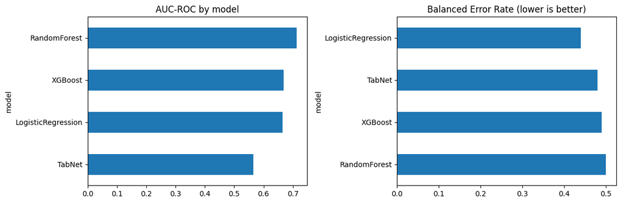

```
Best model by AUC-ROC: RandomForest
TabNet ranks #4 of 4 by AUC-ROC
```

```python
import matplotlib.pyplot as plt

fig, axes = plt.subplots(1, 2, figsize=(12, 4))
results_df["auc_roc"].sort_values().plot.barh(ax=axes[0], title="AUC-ROC by model")
results_df["ber"].sort_values(ascending=False).plot.barh(ax=axes[1], title="Balanced Error Rate (lower is better)")
plt.tight_layout()
plt.savefig("../docs/rq1_model_comparison.png", dpi=150)
plt.show()

best_model = results_df["auc_roc"].idxmax()
tabnet_rank = results_df.index.get_loc("TabNet") + 1
print(f"Best model by AUC-ROC: {best_model}")
print(f"TabNet ranks #{tabnet_rank} of {len(results_df)} by AUC-ROC")
```

## SMOTE robustness check (best tree model only)

**Fixed a real gap**: earlier drafts of this notebook (and the synopsis's own RQ1 methodology) claimed a SMOTE-based robustness check ran "below," but no such code ever existed -- `imbalanced-learn` sat in `requirements.txt` unused. This cell actually implements it, scoped to the winning model only (`best_tree`) rather than repeating the full 4-model CV pass, to keep the added runtime small while still answering the question that matters: does SMOTE fix the threshold-collapse problem class-weighting alone did not?

SMOTE is applied **only to each fold's training split**, never the held- out fold -- resampling before splitting, or resampling the test fold, would leak synthetic-neighbor information across the train/test boundary. `class_weight`/`scale_pos_weight` is dropped for the SMOTE variant, since the training data itself is now balanced -- combining both would double-correct for imbalance.

```python
from imblearn.over_sampling import SMOTE

# Computed locally rather than relying on the later 'Save results' cell --
# that cell defines best_tree too, but this SMOTE check runs before it in
# notebook order, so depending on it there would be a NameError (a real
# bug hit on the first real run, fixed here rather than reordering cells).
tree_only = results_df.loc[results_df.index.intersection(["RandomForest", "XGBoost"])]
best_tree = tree_only["auc_roc"].idxmax()

def make_smote_model(name):
    if name == "RandomForest":
        return RandomForestClassifier(n_estimators=300, random_state=42, n_jobs=-1)
    if name == "XGBoost":
        return XGBClassifier(
            n_estimators=200, max_depth=4, eval_metric="logloss", random_state=42, n_jobs=-1,
        )
    raise ValueError(f"SMOTE check not scoped for model type: {name}")

oof_probs_smote = np.zeros(len(y))

for fold, (train_idx, test_idx) in enumerate(skf.split(X, y)):
    X_train, X_test = X.iloc[train_idx], X.iloc[test_idx]
    y_train, y_test = y.iloc[train_idx], y.iloc[test_idx]

    smote = SMOTE(random_state=42)
    X_train_smote, y_train_smote = smote.fit_resample(X_train, y_train)

    model_smote = make_smote_model(best_tree)
    model_smote.fit(X_train_smote, y_train_smote)
    oof_probs_smote[test_idx] = model_smote.predict_proba(X_test)[:, 1]

    print(f"SMOTE fold {fold + 1}/{N_FOLDS}: train {len(y_train)} -> "
          f"{len(y_train_smote)} after resampling")

preds_cw = (oof_probs[best_tree] >= 0.5).astype(int)
preds_smote = (oof_probs_smote >= 0.5).astype(int)

print(f"\n=== {best_tree}: class-weighted (existing) vs. SMOTE (robustness check), at 0.5 threshold ===")
print(f"Class-weighted: {summarize(y, preds_cw, oof_probs[best_tree])}")
print(f"SMOTE:          {summarize(y, preds_smote, oof_probs_smote)}")

print(
    "\nInterpretation: class-weighting reweights the training LOSS, which is "
    "why it improved AUC-ROC but left predicted probabilities skewed toward "
    "the majority class (never crossing 0.5). SMOTE rebalances the training "
    "DATA itself -- if recall/F1 improve markedly here at the same threshold, "
    "that is direct evidence the threshold-collapse problem is a class-"
    "weighting-specific artifact, not an inherent limit of these models on "
    "this data."
)
```

```
SMOTE fold 1/5: train 1253 -> 2340 after resampling
```

```
SMOTE fold 2/5: train 1253 -> 2340 after resampling
```

```
SMOTE fold 3/5: train 1254 -> 2340 after resampling
```

```
SMOTE fold 4/5: train 1254 -> 2342 after resampling
```

[output not shown]

## Save results for downstream notebooks

Without this step, `03`-`06` would each silently re-derive their own assumptions instead of using what RQ1 actually found. Two things are saved, not one, because the synopsis's own methodology needs both: RQ2's SHAP analysis is scoped to "the best-performing **tree** ensemble" specifically (TreeExplainer only supports tree models), while RQ1's own question -- does TabNet beat tree ensembles -- needs the true overall winner. If those two happen to be the same model, both artifacts just point to it; if not, downstream notebooks get the correct one for what they're actually doing.

```python
from sklearn.model_selection import train_test_split
from artifacts import save_model, save_json, tabnet_save_path

best_overall = results_df["auc_roc"].idxmax()
tree_only = results_df.loc[results_df.index.intersection(["RandomForest", "XGBoost"])]
best_tree = tree_only["auc_roc"].idxmax()

print(f"Best model overall (by AUC-ROC): {best_overall}")
print(f"Best TREE-ensemble model (by AUC-ROC): {best_tree}")
if best_overall != best_tree:
    print(
        f"Note: {best_overall} beat the tree ensembles overall, but RQ2/RQ3's "
        f"SHAP analysis will still use {best_tree} (the best tree model) per "
        f"the synopsis's stated TreeExplainer-based methodology."
    )

def refit_on(name, X_subset, y_subset):
    if name == "LogisticRegression":
        m = Pipeline([
            ("scaler", StandardScaler()),
            ("clf", LogisticRegression(class_weight="balanced", max_iter=2000, random_state=42)),
        ])
        m.fit(X_subset, y_subset)
        return m
    if name == "RandomForest":
        m = RandomForestClassifier(n_estimators=300, class_weight="balanced", random_state=42, n_jobs=-1)
        m.fit(X_subset, y_subset)
        return m
    if name == "XGBoost":
        m = XGBClassifier(
            n_estimators=200, max_depth=4, scale_pos_weight=pos_weight,
            eval_metric="logloss", random_state=42, n_jobs=-1,
        )
        m.fit(X_subset, y_subset)
        return m
    raise ValueError(f"Unexpected model name: {name}")

# Always save the best tree model, fit on ALL data -- this is the "deployed"
# model 03 loads for SHAP's global explanation (explaining the model's
# learned behavior across the whole population is the standard use of SHAP
# here, not a claim about generalization).
best_tree_model = refit_on(best_tree, X, y)
save_model("rq1_best_tree", best_tree_model)

# Separately save the overall winner, refitting on full data only if it
# differs from the tree model already fit above (avoid training TabNet twice).
if best_overall == "TabNet":
    tabnet_full = TabNetClassifier(seed=42, verbose=0)
    tabnet_full.fit(X_arr, y_arr, weights=1, max_epochs=60, patience=10, batch_size=128)
    tabnet_full.save_model(tabnet_save_path("rq1_best_overall_tabnet"))
elif best_overall != best_tree:
    overall_model = refit_on(best_overall, X, y)
    save_model("rq1_best_overall", overall_model)

# A SEPARATE, genuinely held-out model, trained ONLY on a fixed 80/20
# stratified train split -- NOT the same object as rq1_best_tree above.
# rq1_best_tree has already seen 100% of the data, including whatever rows
# end up in test_idx here, so it cannot be used for any downstream
# evaluation that needs genuine held-out data (03's permutation importance,
# 04's full-vs-reduced comparison) -- using it there would silently leak
# training data into what's supposed to be a held-out test.
train_idx, test_idx = train_test_split(
    np.arange(len(y)), test_size=0.2, stratify=y, random_state=42
)
X_train_ho, y_train_ho = X.iloc[train_idx], y.iloc[train_idx]
best_tree_holdout_model = refit_on(best_tree, X_train_ho, y_train_ho)
save_model("rq1_best_tree_holdout", best_tree_holdout_model)

save_json("rq1_holdout_split", {
    "train_idx": train_idx.tolist(),
    "test_idx": test_idx.tolist(),
})

# Save the best tree model's out-of-fold probabilities -- these are
# genuinely out-of-sample for every wafer (unlike a single train/test
# split), so they are the right basis for threshold tuning (e.g. finding
# an F1-optimal cutoff) without overfitting the threshold to one split.
# Plain in-memory variables in this notebook are NOT visible to 03/04/05/06
# -- each runs as its own separate kernel process, so anything downstream
# notebooks need must be explicitly saved here, not assumed to still be in scope.
save_json("rq1_oof_probs", {
    "model_name": best_tree,
    "probs": oof_probs[best_tree].tolist(),
    "y_true": y.tolist(),
})

save_json("rq1_summary", {
    "best_overall_model_name": best_overall,
    "best_tree_model_name": best_tree,
    "screened_feature_count": int(X.shape[1]),
    "feature_names": list(X.columns),
    "results": results_df.reset_index().to_dict(orient="records"),
})

print(
    "\nSaved to data/artifacts/: rq1_best_tree.joblib (full-data, for SHAP), "
    "rq1_best_tree_holdout.joblib (train-only, for held-out evaluation), "
    "rq1_holdout_split.json, rq1_oof_probs.json, rq1_summary.json"
    + (", rq1_best_overall_tabnet.zip" if best_overall == "TabNet"
       else ", rq1_best_overall.joblib" if best_overall != best_tree else "")
)
```

```
Best model overall (by AUC-ROC): RandomForest
Best TREE-ensemble model (by AUC-ROC): RandomForest
```

```
Saved to data/artifacts/: rq1_best_tree.joblib (full-data, for SHAP), rq1_best_tree_holdout.joblib (train-only, for held-out evaluation), rq1_holdout_split.json, rq1_oof_probs.json, rq1_summary.json
```

## Export

Run the cell below last to export this notebook to a standalone HTML file.

```python
# --- Export this notebook to HTML (run this cell last) ---
# Works whether opened live from GitHub in Colab or run locally in Jupyter.
import json
import subprocess

NOTEBOOK_NAME = "02_modeling_rq1"

try:
    import google.colab
    IN_COLAB = True
except ImportError:
    IN_COLAB = False

export_path = f"{NOTEBOOK_NAME}.ipynb"
live_export_available = False

if IN_COLAB:
    # Colab's own notebook JSON isn't the same file as the clone on disk --
    # this pulls the live, currently-run state (including your outputs)
    # directly from the Colab frontend, so nothing gets missed. This only
    # works when there's an actual live frontend attached (i.e. you're running
    # this cell interactively yourself) -- it returns None instead of raising
    # when run unattended (e.g. via 00_run_all.ipynb's automated execution),
    # so that case is caught explicitly here rather than left to crash with a
    # raw TypeError, which used to make 00_run_all's --allow-errors flag mask
    # *real* failures elsewhere in the notebook, not just this expected one.
    from google.colab import _message
    response = _message.blocking_request('get_ipynb', timeout_sec=30)
    if response is not None:
        ipynb_content = response['ipynb']
        with open(export_path, 'w') as f:
            json.dump(ipynb_content, f)
        live_export_available = True
    else:
        print(
            "No live Colab frontend detected (expected when run via "
            "00_run_all.ipynb) -- skipping the live export. 00_run_all does its "
            "own separate HTML export against the already-executed file instead."
        )

if live_export_available or not IN_COLAB:
    html_output = f"{NOTEBOOK_NAME}.html"
    result = subprocess.run(
        ['jupyter', 'nbconvert', '--to', 'html', export_path, '--output', html_output],
        capture_output=True, text=True,
    )
    print(result.stdout)
    if result.returncode != 0:
        print(result.stderr)
    else:
        print(f"Exported to {html_output}")

    if IN_COLAB and result.returncode == 0:
        from google.colab import files
        files.download(html_output)
```

```
No live Colab frontend detected (expected when run via 00_run_all.ipynb) -- skipping the live export. 00_run_all does its own separate HTML export against the already-executed file instead.
```